# Tidyverse Sample Exam v2.0 Solutions

[Brendan Cullen](https://bcullen.rbind.io/)

[figure not shown]

### Instructions

1. This exam covers material from [R for Data Science](https://r4ds.had.co.nz/). You may find the [study guide](https://jrnold.github.io/r4ds-exercise-solutions/) useful. If you have any questions about scope, please get in touch.
2. You must complete the exam within 90 minutes.
3. You may use any books or digital resources you want during this examination, but you may not communicate with any person other than your examiner.
4. You are required to use the RStudio IDE for the practical portions of this exam. You may use either the desktop edition or rstudio.cloud as you prefer.

There is of course no one correct way to solve each of these questions. I’ve included the solutions that first came to my mind when I did this practice exam. If you find a mistake or a better solution, please feel free to submit a pull request on [Github](https://github.com/brendanhcullen/tidyverse-sample-exam-v2.0).

You can download the blank sample exam `.rmd` here. You can download this current `.rmd` containing the solutions here.

By default, the code for each solution is hidden. You can toggle the code on and off by clicking `Code`/`Hide` at the top right of each chunk or `Code > Show All Code / Hide All Code` at the top right of this document.

```r
library(tidyverse)
```

### Basic Operations

1. Read the file `person.csv` and store the result in a tibble called `person`.

```r
(person <- read_csv(here::here("person.csv")))
```

| person_id | personal_name | family_name |
| --- | --- | --- |
| dyer | William | Dyer |
| pb | Frank | Pabodie |
| lake | Anderson | Lake |
| roe | Valentina | Roerich |
| danforth | Frank | Danforth |

2. Create a tibble containing only family and personal names, in that order. You do not need to assign this tibble or any others to variables unless explicitly asked to do so. However, as noted in the introduction, you *must* use the pipe operator `%>%` and code that follows the tidyverse style guide.

```r
person %>%
  select(family_name, personal_name)
```

| family_name | personal_name |
| --- | --- |
| Dyer | William |
| Pabodie | Frank |
| Lake | Anderson |
| Roerich | Valentina |
| Danforth | Frank |

3. Create a new tibble containing only the rows in which family names come *before* the letter `M`. Your solution should work for tables with more rows than the example, i.e., you cannot rely on row numbers or select specific names.

```r
before_m <- letters[which(letters == "a"):which(letters == "m") - 1]

person %>%
  mutate(family_name = tolower(family_name),
         family_first_letter = str_sub(family_name, 1, 1)) %>%
  filter(family_first_letter %in% before_m) %>%
  select(-family_first_letter)
```

| person_id | personal_name | family_name |
| --- | --- | --- |
| dyer | William | dyer |
| lake | Anderson | lake |
| danforth | Frank | danforth |

Another, much more elegant solution, courtesy of [Beatriz Milz](https://education.rstudio.com/trainers/people/milz+beatriz/):

```r
person %>% filter(family_name < "M")
```

| person_id | personal_name | family_name |
| --- | --- | --- |
| dyer | William | Dyer |
| lake | Anderson | Lake |
| danforth | Frank | Danforth |

4. Display all the rows in `person` sorted by family name length with the longest name first.

```r
person %>%
  arrange(desc(str_length(family_name)))
```

| person_id | personal_name | family_name |
| --- | --- | --- |
| danforth | Frank | Danforth |
| pb | Frank | Pabodie |
| roe | Valentina | Roerich |
| dyer | William | Dyer |
| lake | Anderson | Lake |

### Cleaning and Counting

1. Read the file `measurements.csv` to create a tibble called `measurements`. (The strings `"rad"`, `"sal"`, and `"temp"` in the `quantity` column stand for “radiation”, “salinity”, and “temperature” respectively.)

```r
(measurements <- read_csv(here::here("measurements.csv")))
```

| visit_id | visitor | quantity | reading |
| --- | --- | --- | --- |
| 619 | dyer | rad | 9.82 |
| 619 | dyer | sal | 0.13 |
| 622 | dyer | rad | 7.80 |
| 622 | dyer | sal | 0.09 |
| 734 | pb | rad | 8.41 |
| 734 | lake | sal | 0.05 |
| 734 | pb | temp | -21.50 |
| 735 | pb | rad | 7.22 |
| 735 | NA | sal | 0.06 |
| 735 | NA | temp | -26.00 |

[output cut: 11 more lines]

2. Create a tibble containing only rows where *none* of the values are `NA` and save in a tibble called `cleaned`.

```r
(cleaned <- measurements %>%
  drop_na())
```

| visit_id | visitor | quantity | reading |
| --- | --- | --- | --- |
| 619 | dyer | rad | 9.82 |
| 619 | dyer | sal | 0.13 |
| 622 | dyer | rad | 7.80 |
| 622 | dyer | sal | 0.09 |
| 734 | pb | rad | 8.41 |
| 734 | lake | sal | 0.05 |
| 734 | pb | temp | -21.50 |
| 735 | pb | rad | 7.22 |
| 751 | pb | rad | 4.35 |
| 751 | pb | temp | -18.50 |

[output cut: 8 more lines]

3. Count the number of measurements of each type of quantity in `cleaned`. Your result should have one row for each quantity `"rad"`, `"sal"`, and `"temp"`.

```r
cleaned %>%
  count(quantity)
```

| quantity | n |
| --- | --- |
| rad | 8 |
| sal | 7 |
| temp | 3 |

4. Display the minimum and maximum value of `reading` separately for each quantity in `cleaned`. Your result should have one row for each quantity `"rad"`, `"sal"`, and `"temp"`.

```r
cleaned %>%
  group_by(quantity) %>%
  summarize(reading_min = min(reading),
            reading_max = max(reading))
```

| quantity | reading_min | reading_max |
| --- | --- | --- |
| rad | 1.46 | 11.25 |
| sal | 0.05 | 41.60 |
| temp | -21.50 | -16.00 |

**Note: You could also use `dplyr::across()` and a named list of functions!** 😎

```r
cleaned %>%
  group_by(quantity) %>%
  summarize(across(reading, list(min = min, max = max)))
```

| quantity | reading_min | reading_max |
| --- | --- | --- |
| rad | 1.46 | 11.25 |
| sal | 0.05 | 41.60 |
| temp | -21.50 | -16.00 |

5. Create a tibble in which all salinity (`"sal"`) readings greater than 1 are divided by 100. (This is needed because some people wrote percentages as numbers from 0.0 to 1.0, but others wrote them as 0.0 to 100.0.)

```r
cleaned %>%
  mutate(reading = case_when(
                      quantity == "sal" & reading > 1 ~ reading/100,
                      TRUE ~ reading)
         )
```

| visit_id | visitor | quantity | reading |
| --- | --- | --- | --- |
| 619 | dyer | rad | 9.820 |
| 619 | dyer | sal | 0.130 |
| 622 | dyer | rad | 7.800 |
| 622 | dyer | sal | 0.090 |
| 734 | pb | rad | 8.410 |
| 734 | lake | sal | 0.050 |
| 734 | pb | temp | -21.500 |
| 735 | pb | rad | 7.220 |
| 751 | pb | rad | 4.350 |
| 751 | pb | temp | -18.500 |

[output cut: 8 more lines]

### Combining Data

1. Read `visited.csv` and drop rows containing any `NA`s, assigning the result to a new tibble called `visited`.

```r
(visited <- read_csv(here::here("visited.csv")) %>%
  drop_na())
```

| visit_id | site_id | visit_date |
| --- | --- | --- |
| 619 | DR-1 | 1927-02-08 |
| 622 | DR-1 | 1927-02-10 |
| 734 | DR-3 | 1930-01-07 |
| 735 | DR-3 | 1930-01-12 |
| 751 | DR-3 | 1930-02-26 |
| 837 | MSK-4 | 1932-01-14 |
| 844 | DR-1 | 1932-03-22 |

2. Use an inner join to combine `visited` with `cleaned` using the `visit_id` column for matches.

```r
(combined <- inner_join(visited, cleaned, by = "visit_id"))
```

| visit_id | site_id | visit_date | visitor | quantity | reading |
| --- | --- | --- | --- | --- | --- |
| 619 | DR-1 | 1927-02-08 | dyer | rad | 9.82 |
| 619 | DR-1 | 1927-02-08 | dyer | sal | 0.13 |
| 622 | DR-1 | 1927-02-10 | dyer | rad | 7.80 |
| 622 | DR-1 | 1927-02-10 | dyer | sal | 0.09 |
| 734 | DR-3 | 1930-01-07 | pb | rad | 8.41 |
| 734 | DR-3 | 1930-01-07 | lake | sal | 0.05 |
| 734 | DR-3 | 1930-01-07 | pb | temp | -21.50 |
| 735 | DR-3 | 1930-01-12 | pb | rad | 7.22 |
| 751 | DR-3 | 1930-02-26 | pb | rad | 4.35 |
| 751 | DR-3 | 1930-02-26 | pb | temp | -18.50 |

[output cut: 4 more lines]

3. Find the highest radiation (`"rad"`) reading at each site. (Sites are identified by values in the `site_id` column.)

```r
(max_rad <- combined %>%
  pivot_wider(names_from = quantity, values_from = reading) %>%
  group_by(site_id) %>%
  summarize(max_rad = max(rad, na.rm = TRUE)))
```

| site_id | max_rad |
| --- | --- |
| DR-1 | 11.25 |
| DR-3 | 8.41 |
| MSK-4 | 1.46 |

4. Find the date of the highest radiation reading at each site.

```r
combined %>%
  pivot_wider(names_from = quantity, values_from = reading) %>%
  group_by(site_id, visit_date) %>%
  summarize(max_rad = max(rad, na.rm = TRUE)) %>%
  semi_join(max_rad) %>%
  select(visit_date, everything())
```

| visit_date | site_id | max_rad |
| --- | --- | --- |
| 1932-03-22 | DR-1 | 11.25 |
| 1930-01-07 | DR-3 | 8.41 |
| 1932-01-14 | MSK-4 | 1.46 |

### Plotting

1. The code below is supposed to read the file `home-range-database.csv` to create a tibble called `hra_raw`, but contains a bug. Describe and fix the problem. (There are several ways to fix it: please use whichever you prefer.)

```r
hra_raw <- read_csv(here::here("data", "home-range-database.csv"))
```

**Note: The file `home-range-database.csv` is currently saved in the root directory of the project, not in a subdirectory called `data`, as the code above would suggest. You could either create the `data` folder and move the data file there, or you could update the code that imports the data (as I demonstrate below).**

```r
(hra_raw <- read_csv(here::here("home-range-database.csv")))
```

| taxon | common.name | class | order | family | genus | species | primarymethod | N | mean.mass.g | log10.mass | alternative.mass.reference | mean.hra.m2 | log10.hra | hra.reference | realm | thermoregulation | locomotion | trophic.guild | dimension | preymass | log10.preymass | PPMR | prey.size.reference |
| --- | --- | --- | --- | --- | --- | --- | --- | --- | --- | --- | --- | --- | --- | --- | --- | --- | --- | --- | --- | --- | --- | --- | --- |
| lake fishes | american eel | actinopterygii | anguilliformes | anguillidae | anguilla | rostrata | telemetry | 16 | 887.00 | 2.94792362 | NA | 2.827500e+05 | 5.45140261 | Minns, C. K. 1995. Allometry of home range size in lake and river fishes. Canadian Journal of Fisheries and Aquatic Sciences 52:1499-1508. | aquatic | ectotherm | swimming | carnivore | 3D | NA | NA | NA | NA |
| river fishes | blacktail redhorse | actinopterygii | cypriniformes | catostomidae | moxostoma | poecilura | mark-recapture | NA | 562.00 | 2.74973632 | NA | 2.821000e+02 | 2.45040309 | Minns, C. K. 1995. Allometry of home range size in lake and river fishes. Canadian Journal of Fisheries and Aquatic Sciences 52:1499-1508. | aquatic | ectotherm | swimming | carnivore | 2D | NA | NA | NA | NA |
| river fishes | central stoneroller | actinopterygii | cypriniformes | cyprinidae | campostoma | anomalum | mark-recapture | 20 | 34.00 | 1.53147892 | NA | 1.161100e+02 | 2.06486963 | Minns, C. K. 1995. Allometry of home range size in lake and river fishes. Canadian Journal of Fisheries and Aquatic Sciences 52:1499-1508. | aquatic | ectotherm | swimming | carnivore | 2D | NA | NA | NA | NA |
| river fishes | rosyside dace | actinopterygii | cypriniformes | cyprinidae | clinostomus | funduloides | mark-recapture | 26 | 4.00 | 0.60205999 | NA | 1.255000e+02 | 2.09864373 | Minns, C. K. 1995. Allometry of home range size in lake and river fishes. Canadian Journal of Fisheries and Aquatic Sciences 52:1499-1508. | aquatic | ectotherm | swimming | carnivore | 2D | NA | NA | NA | NA |
| river fishes | longnose dace | actinopterygii | cypriniformes | cyprinidae | rhinichthys | cataractae | mark-recapture | 17 | 4.00 | 0.60205999 | NA | 8.710000e+01 | 1.94001815 | Minns, C. K. 1995. Allometry of home range size in lake and river fishes. Canadian Journal of Fisheries and Aquatic Sciences 52:1499-1508. | aquatic | ectotherm | swimming | carnivore | 2D | NA | NA | NA | NA |
| river fishes | muskellunge | actinopterygii | esociformes | esocidae | esox | masquinongy | telemetry | 5 | 3525.00 | 3.54715912 | NA | 3.934350e+04 | 4.59487299 | Minns, C. K. 1995. Allometry of home range size in lake and river fishes. Canadian Journal of Fisheries and Aquatic Sciences 52:1499-1508. | aquatic | ectotherm | swimming | carnivore | 2D | NA | NA | NA | NA |
| marine fishes | pollack | actinopterygii | gadiformes | gadidae | pollachius | pollachius | telemetry | 2 | 737.36 | 2.86767957 | NA | 9.056410e+03 | 3.95695608 | Sarno B, Glass CW, Smith GW, et al. 1994. A comparison of the movements of two species of gadoid in the vicinity of an underwater reef. Journal of Fisheries Biology 45, 811-817. | aquatic | ectotherm | swimming | carnivore | 2D | 1.39 | 0.1430148 | 530.000000 | Brose U, et al. 2005b. Body sizes of consumers and their resources. Ecology 86, 2545. |
| marine fishes | saithe | actinopterygii | gadiformes | gadidae | pollachius | virens | telemetry | 2 | 448.61 | 2.65186895 | NA | 4.451615e+04 | 4.64851760 | Sarno B, Glass CW, Smith GW, et al. 1994. A comparison of the movements of two species of gadoid in the vicinity of an underwater reef. Journal of Fisheries Biology 45, 811-817. | aquatic | ectotherm | swimming | carnivore | 2D | NA | NA | NA | NA |
| marine fishes | lined surgeonfish | actinopterygii | perciformes | acanthuridae | acanthurus | lineatus | direct observation | NA | 109.04 | 2.03758584 | NA | 1.113000e+01 | 1.04649516 | Nursall JR. 1974. Some Territorial Behavioral Attributes of the Surgeonfish Acanthurus lineatus at Heron Island, Queensland. Copeia 950-959. | aquatic | ectotherm | swimming | herbivore | 2D | NA | NA | NA | NA |
| marine fishes | orangespine unicornfish | actinopterygii | perciformes | acanthuridae | naso | lituratus | telemetry | 8 | 772.16 | 2.88770730 | NA | 3.209286e+04 | 4.50640842 | Marshell A, Mills JS, Rhodes KL, et al. 2011. Passive acoustic telemetry reveals highly variable home range and movement patterns among unicornfish within a marine reserve. Coral Reefs 30, 631-642. | aquatic | ectotherm | swimming | herbivore | 2D | NA | NA | NA | NA |

[output cut: 556 more lines]

2. Convert the `class` column (which is text) to create a factor column `class_fct` and assign the result to a tibble `hra`. Use `forcats` to order the factor levels as:
   1. mammalia
   2. reptilia
   3. aves
   4. actinopterygii

```r
(hra <- hra_raw %>%
  mutate(class_fct = factor(class, levels = c("mammalia",
                                              "reptilia",
                                              "aves",
                                              "actinopterygii"))) %>%
   relocate(class_fct, .after = class))
```

| taxon | common.name | class | class_fct | order | family | genus | species | primarymethod | N | mean.mass.g | log10.mass | alternative.mass.reference | mean.hra.m2 | log10.hra | hra.reference | realm | thermoregulation | locomotion | trophic.guild | dimension | preymass | log10.preymass | PPMR | prey.size.reference |
| --- | --- | --- | --- | --- | --- | --- | --- | --- | --- | --- | --- | --- | --- | --- | --- | --- | --- | --- | --- | --- | --- | --- | --- | --- |
| lake fishes | american eel | actinopterygii | actinopterygii | anguilliformes | anguillidae | anguilla | rostrata | telemetry | 16 | 887.00 | 2.94792362 | NA | 2.827500e+05 | 5.45140261 | Minns, C. K. 1995. Allometry of home range size in lake and river fishes. Canadian Journal of Fisheries and Aquatic Sciences 52:1499-1508. | aquatic | ectotherm | swimming | carnivore | 3D | NA | NA | NA | NA |
| river fishes | blacktail redhorse | actinopterygii | actinopterygii | cypriniformes | catostomidae | moxostoma | poecilura | mark-recapture | NA | 562.00 | 2.74973632 | NA | 2.821000e+02 | 2.45040309 | Minns, C. K. 1995. Allometry of home range size in lake and river fishes. Canadian Journal of Fisheries and Aquatic Sciences 52:1499-1508. | aquatic | ectotherm | swimming | carnivore | 2D | NA | NA | NA | NA |
| river fishes | central stoneroller | actinopterygii | actinopterygii | cypriniformes | cyprinidae | campostoma | anomalum | mark-recapture | 20 | 34.00 | 1.53147892 | NA | 1.161100e+02 | 2.06486963 | Minns, C. K. 1995. Allometry of home range size in lake and river fishes. Canadian Journal of Fisheries and Aquatic Sciences 52:1499-1508. | aquatic | ectotherm | swimming | carnivore | 2D | NA | NA | NA | NA |
| river fishes | rosyside dace | actinopterygii | actinopterygii | cypriniformes | cyprinidae | clinostomus | funduloides | mark-recapture | 26 | 4.00 | 0.60205999 | NA | 1.255000e+02 | 2.09864373 | Minns, C. K. 1995. Allometry of home range size in lake and river fishes. Canadian Journal of Fisheries and Aquatic Sciences 52:1499-1508. | aquatic | ectotherm | swimming | carnivore | 2D | NA | NA | NA | NA |
| river fishes | longnose dace | actinopterygii | actinopterygii | cypriniformes | cyprinidae | rhinichthys | cataractae | mark-recapture | 17 | 4.00 | 0.60205999 | NA | 8.710000e+01 | 1.94001815 | Minns, C. K. 1995. Allometry of home range size in lake and river fishes. Canadian Journal of Fisheries and Aquatic Sciences 52:1499-1508. | aquatic | ectotherm | swimming | carnivore | 2D | NA | NA | NA | NA |
| river fishes | muskellunge | actinopterygii | actinopterygii | esociformes | esocidae | esox | masquinongy | telemetry | 5 | 3525.00 | 3.54715912 | NA | 3.934350e+04 | 4.59487299 | Minns, C. K. 1995. Allometry of home range size in lake and river fishes. Canadian Journal of Fisheries and Aquatic Sciences 52:1499-1508. | aquatic | ectotherm | swimming | carnivore | 2D | NA | NA | NA | NA |
| marine fishes | pollack | actinopterygii | actinopterygii | gadiformes | gadidae | pollachius | pollachius | telemetry | 2 | 737.36 | 2.86767957 | NA | 9.056410e+03 | 3.95695608 | Sarno B, Glass CW, Smith GW, et al. 1994. A comparison of the movements of two species of gadoid in the vicinity of an underwater reef. Journal of Fisheries Biology 45, 811-817. | aquatic | ectotherm | swimming | carnivore | 2D | 1.39 | 0.1430148 | 530.000000 | Brose U, et al. 2005b. Body sizes of consumers and their resources. Ecology 86, 2545. |
| marine fishes | saithe | actinopterygii | actinopterygii | gadiformes | gadidae | pollachius | virens | telemetry | 2 | 448.61 | 2.65186895 | NA | 4.451615e+04 | 4.64851760 | Sarno B, Glass CW, Smith GW, et al. 1994. A comparison of the movements of two species of gadoid in the vicinity of an underwater reef. Journal of Fisheries Biology 45, 811-817. | aquatic | ectotherm | swimming | carnivore | 2D | NA | NA | NA | NA |
| marine fishes | lined surgeonfish | actinopterygii | actinopterygii | perciformes | acanthuridae | acanthurus | lineatus | direct observation | NA | 109.04 | 2.03758584 | NA | 1.113000e+01 | 1.04649516 | Nursall JR. 1974. Some Territorial Behavioral Attributes of the Surgeonfish Acanthurus lineatus at Heron Island, Queensland. Copeia 950-959. | aquatic | ectotherm | swimming | herbivore | 2D | NA | NA | NA | NA |
| marine fishes | orangespine unicornfish | actinopterygii | actinopterygii | perciformes | acanthuridae | naso | lituratus | telemetry | 8 | 772.16 | 2.88770730 | NA | 3.209286e+04 | 4.50640842 | Marshell A, Mills JS, Rhodes KL, et al. 2011. Passive acoustic telemetry reveals highly variable home range and movement patterns among unicornfish within a marine reserve. Coral Reefs 30, 631-642. | aquatic | ectotherm | swimming | herbivore | 2D | NA | NA | NA | NA |

[output cut: 556 more lines]

3. Create a scatterplot showing the relationship between `log10.mass` and `log10.hra` in `hra`.

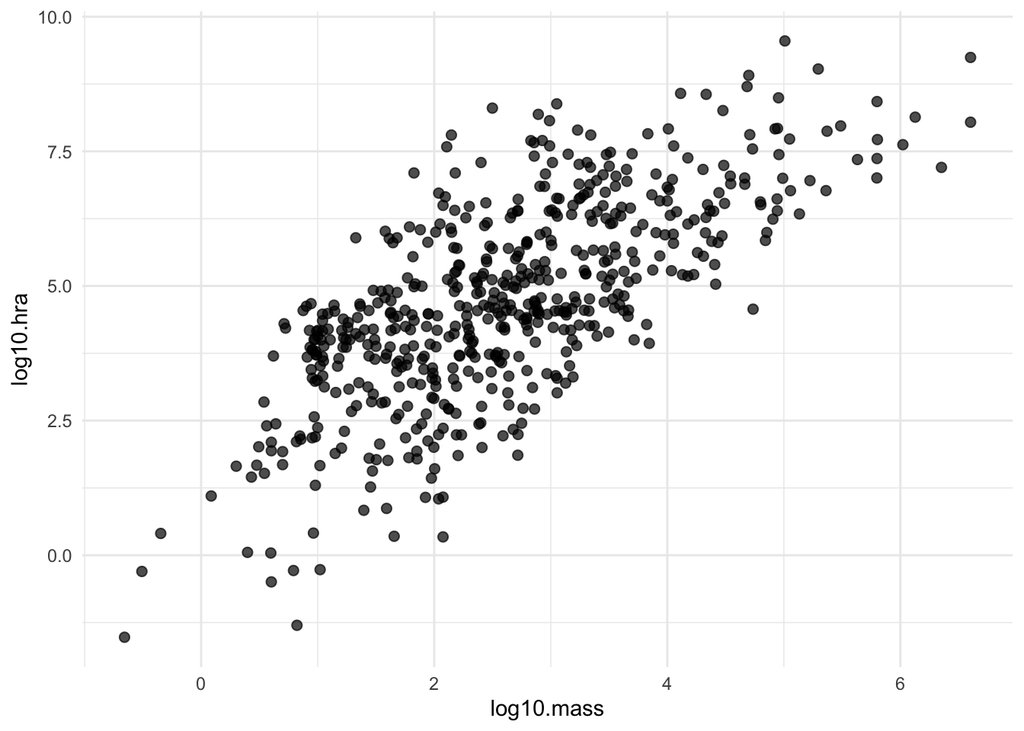

```r
hra %>%
  ggplot(aes(log10.mass, log10.hra)) +
  geom_point(size = 2, alpha = 0.7) +
  theme_minimal()
```

4. Colorize the points in the scatterplot by `class_fct`.

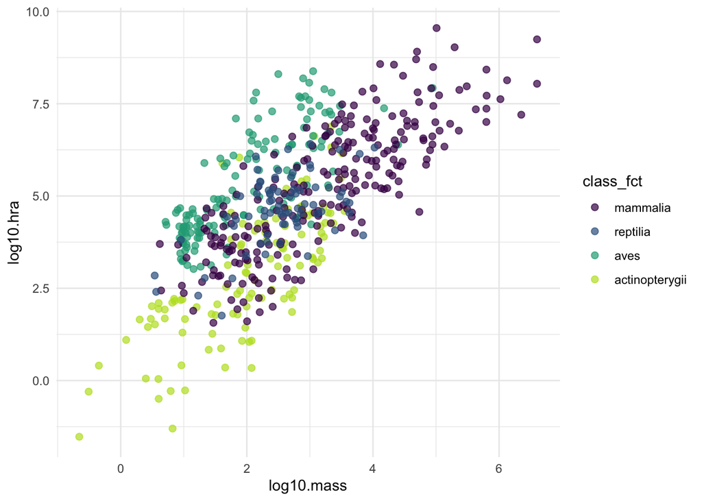

```r
hra %>%
  ggplot(aes(log10.mass, log10.hra, color = class_fct)) +
  geom_point(size = 2, alpha = 0.7) +
  scale_color_viridis_d(end = .9) +
  theme_minimal()
```

5. Display a scatterplot showing only data for birds (class `aves`) and fit a linear regression to that data using the `lm` function.

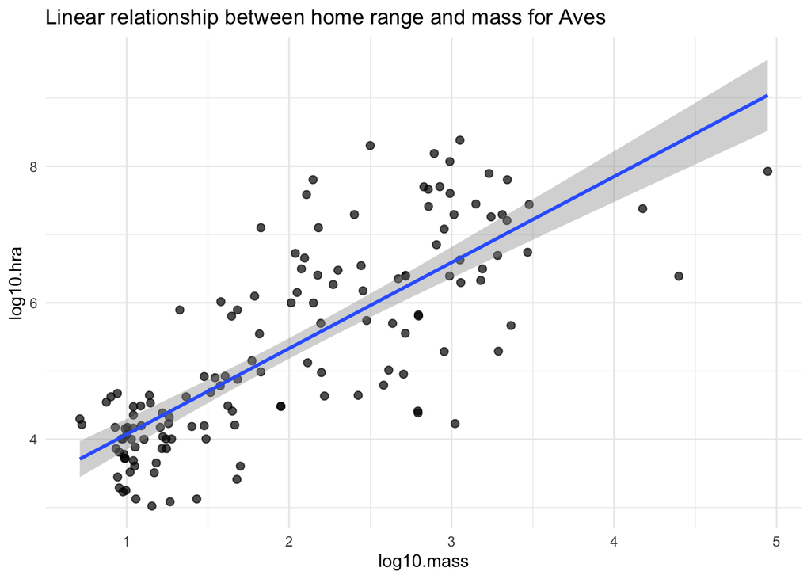

```r
hra %>%
  filter(class == "aves") %>%
  ggplot(aes(log10.mass, log10.hra)) +
  geom_point(size = 2, alpha = 0.7) +
  geom_smooth(method = "lm") +
  labs(title = "Linear relationship between home range and mass for Aves") +
  theme_minimal()
```

### Functional Programming

1. Write a function called `summarize_table` that takes a title string and a tibble as input and returns a string that says something like, “*title* has *#* rows and *#* columns”. For example, `summarize_table('our table', person)` should return the string `"our table has 5 rows and 3 columns"`.

```r
summarize_table <- function(title, df) {
  nrow <- nrow(df)
  ncol <- ncol(df)

  glue::glue("{title} has {nrow} rows and {ncol} columns.")
}

summarize_table("our table", person)
```

```
## our table has 5 rows and 3 columns.
```

2. Write another function called `show_columns` that takes a string and a tibble as input and returns a string that says something like, “*table* has columns *name*, *name*, *name*”. For example, `show_columns('person', person)` should return the string `"person has columns person_id, personal_name, family_name"`.

```r
show_columns <- function(title, df) {
  col_names <- names(df) %>%
    str_c(collapse = ", ")

glue::glue("{title} has columns {col_names}")
}

show_columns('person', person)
```

```
## person has columns person_id, personal_name, family_name
```

3. The function `rows_from_file` returns the first *N* rows from a table in a CSV file given the file’s name and the number of rows desired. Modify it so that if no value is specified for the number of rows, a default of 3 is used.

```r
rows_from_file <- function(filename, num_rows) {
      readr::read_csv(filename) %>% head(n = num_rows)
    }

rows_from_file("measurements.csv") # should show 3 rows
```

```r
rows_from_file <- function(filename, num_rows = 3) {
  readr::read_csv(filename) %>% head(n = num_rows)
}

rows_from_file("measurements.csv")
```

| visit_id | visitor | quantity | reading |
| --- | --- | --- | --- |
| 619 | dyer | rad | 9.82 |
| 619 | dyer | sal | 0.13 |
| 622 | dyer | rad | 7.80 |

4. The function `long_name` checks whether a string is longer than 4 characters. Use this function and a function from `purrr` to create a logical vector that contains the value `TRUE` where family names in the tibble `person` are longer than 4 characters, and `FALSE` where they are 4 characters or less.

```r
long_name <- function(name) {
      stringr::str_length(name) > 4
    }
```

```r
person %>%
  mutate(long_family_name = map_lgl(family_name, long_name))
```

| person_id | personal_name | family_name | long_family_name |
| --- | --- | --- | --- |
| dyer | William | Dyer | FALSE |
| pb | Frank | Pabodie | TRUE |
| lake | Anderson | Lake | FALSE |
| roe | Valentina | Roerich | TRUE |
| danforth | Frank | Danforth | TRUE |

### Wrapping Up

1. Modify the YAML header of this file so that a table of contents is automatically created each time this document is knit, and fix any errors that are preventing the document from knitting cleanly.

```
---
title: "Tidyverse Exam Version 2.0"
output:
html_document:
    theme: flatly
---
```

**Corrected YAML header:**

```
---
title: "Tidyverse Exam Version 2.0"
output:
  html_document:
    theme: flatly
    toc: TRUE
---
```

**Note: You need to add an indentation after `html_document:` and add `toc: TRUE`**

You can read more about the RStudio Instructor Training and Certification Program [here](https://education.rstudio.com/trainers/). There is [another sample exam](https://education.rstudio.com/blog/2020/02/instructor-certification-exams/#tidyverse-certification-exam) available with [solutions](https://marlycormar.github.io/tidyverse_sample_exam/sample_exam_sols/sols.html), courtesy of [Marly Gotti](https://www.marlygotti.com/). I wrote about my own experience with the training and shared some of my exam prep materials [here](https://bcullen.rbind.io/post/2020-09-03-reflections-on-rstudio-instructor-training/). Feel free to [reach out](https://twitter.com/_bcullen) with any questions!